# Dataset Analysis

The *Adult Dataset*, from a 1994 US Census, contains information on a set of citizens, including their age, workclass, final weight, education, marital status, relationship, race, sex, capital gain, capital loss, occupation, work hours per week and native country.

```python
import pandas as pd
import matplotlib.pyplot as plt
from helpers import get_stats
%matplotlib inline
```

```python
names = ['age', 'workclass', 'fnlwgt', 'education', 'education-num', 'marital-status', 'occupation', 'relationship', 'race', 'sex',
         'capital-gain', 'capital-loss', 'hours-per-week', 'native-country', 'class']

adult_df = pd.read_csv("data/adult.data", sep=r"\s*,\s*", na_values="?", names=names, engine="python", index_col=False)
adult_df.head()
```

|  | age | workclass | fnlwgt | education | education-num | marital-status | occupation | relationship | race | sex | capital-gain | capital-loss | hours-per-week | native-country | class |
| --- | --- | --- | --- | --- | --- | --- | --- | --- | --- | --- | --- | --- | --- | --- | --- |
| 0 | 39 | State-gov | 77516 | Bachelors | 13 | Never-married | Adm-clerical | Not-in-family | White | Male | 2174 | 0 | 40 | United-States | <=50K |
| 1 | 50 | Self-emp-not-inc | 83311 | Bachelors | 13 | Married-civ-spouse | Exec-managerial | Husband | White | Male | 0 | 0 | 13 | United-States | <=50K |
| 2 | 38 | Private | 215646 | HS-grad | 9 | Divorced | Handlers-cleaners | Not-in-family | White | Male | 0 | 0 | 40 | United-States | <=50K |
| 3 | 53 | Private | 234721 | 11th | 7 | Married-civ-spouse | Handlers-cleaners | Husband | Black | Male | 0 | 0 | 40 | United-States | <=50K |
| 4 | 28 | Private | 338409 | Bachelors | 13 | Married-civ-spouse | Prof-specialty | Wife | Black | Female | 0 | 0 | 40 | Cuba | <=50K |

## Feature Analysis

This dataset is comprised of both numeric and categorical values. Moreover, the categorical values cannot be easily converted into numerical, which would be the case if the categories were, for example, "True" and "False" or "Low", "Medium" and "High". This being the case, to be able to use a KNN classifier, the categorical features were dropped.

```python
numeric_names = ['age', 'fnlwgt', 'education-num', 'capital-gain', 'capital-loss', 'hours-per-week']

numeric_adult_df = adult_df[numeric_names]
numeric_adult_df.head()
```

|  | age | fnlwgt | education-num | capital-gain | capital-loss | hours-per-week |
| --- | --- | --- | --- | --- | --- | --- |
| 0 | 39 | 77516 | 13 | 2174 | 0 | 40 |
| 1 | 50 | 83311 | 13 | 0 | 0 | 13 |
| 2 | 38 | 215646 | 9 | 0 | 0 | 40 |
| 3 | 53 | 234721 | 7 | 0 | 0 | 40 |
| 4 | 28 | 338409 | 13 | 0 | 0 | 40 |

The second issue that must be dealt with is the range of each numeric feature, as a difference of 20 in age means something different from a difference of 20 in work hours. To normalize the data, all values are changed to fall within the range of 0 to 1. This is the main dataset used in the KNN classifier.

```python
from sklearn.preprocessing import MinMaxScaler
```

```python
scaler = MinMaxScaler()
scaler.fit(numeric_adult_df)

scaled_data = scaler.transform(numeric_adult_df)
scaled_adult_df = pd.DataFrame(data=scaled_data, columns=numeric_names)
scaled_adult_df.head()
```

|  | age | fnlwgt | education-num | capital-gain | capital-loss | hours-per-week |
| --- | --- | --- | --- | --- | --- | --- |
| 0 | 0.301370 | 0.044302 | 0.800000 | 0.02174 | 0.0 | 0.397959 |
| 1 | 0.452055 | 0.048238 | 0.800000 | 0.00000 | 0.0 | 0.122449 |
| 2 | 0.287671 | 0.138113 | 0.533333 | 0.00000 | 0.0 | 0.397959 |
| 3 | 0.493151 | 0.151068 | 0.400000 | 0.00000 | 0.0 | 0.397959 |
| 4 | 0.150685 | 0.221488 | 0.800000 | 0.00000 | 0.0 | 0.397959 |

Finally, a discretized version of the numeric dataset is also used as a point of comparison for the scaled dataset, as they both coerce the data into falling within a specific range. The number of groups chosen is 5 and the groups are separated uniformly.

```python
from sklearn.preprocessing import KBinsDiscretizer
```

```python
enc = KBinsDiscretizer(n_bins=5, encode='ordinal', strategy="uniform")
discretized_data = enc.fit_transform(numeric_adult_df)

discretized_adult_df = pd.DataFrame(columns=numeric_names, data=discretized_data)
discretized_adult_df.head()
```

|  | age | fnlwgt | education-num | capital-gain | capital-loss | hours-per-week |
| --- | --- | --- | --- | --- | --- | --- |
| 0 | 1.0 | 0.0 | 4.0 | 0.0 | 0.0 | 1.0 |
| 1 | 2.0 | 0.0 | 4.0 | 0.0 | 0.0 | 0.0 |
| 2 | 1.0 | 0.0 | 2.0 | 0.0 | 0.0 | 1.0 |
| 3 | 2.0 | 0.0 | 2.0 | 0.0 | 0.0 | 1.0 |
| 4 | 0.0 | 1.0 | 4.0 | 0.0 | 0.0 | 1.0 |

## Missing Data

To deal with missing data, first we must check the number of missing values per column:

```python
{name: numeric_adult_df[name].isna().sum() for name in numeric_names}
```

```
{'age': 0,
 'fnlwgt': 0,
 'education-num': 0,
 'capital-gain': 0,
 'capital-loss': 0,
 'hours-per-week': 0}
```

As there is no missing values in the numeric columns, a solution will not be needed for the KNN classfier.

## Test Data

```python
test_df = pd.read_csv("data/adult.test", sep=r"\s*,\s*", na_values="?", names=names, engine="python", index_col=False, skiprows=1)
test_df["class"] = test_df["class"].str.replace(".", "", regex=False)
test_df.head()
```

|  | age | workclass | fnlwgt | education | education-num | marital-status | occupation | relationship | race | sex | capital-gain | capital-loss | hours-per-week | native-country | class |
| --- | --- | --- | --- | --- | --- | --- | --- | --- | --- | --- | --- | --- | --- | --- | --- |
| 0 | 25 | Private | 226802 | 11th | 7 | Never-married | Machine-op-inspct | Own-child | Black | Male | 0 | 0 | 40 | United-States | <=50K |
| 1 | 38 | Private | 89814 | HS-grad | 9 | Married-civ-spouse | Farming-fishing | Husband | White | Male | 0 | 0 | 50 | United-States | <=50K |
| 2 | 28 | Local-gov | 336951 | Assoc-acdm | 12 | Married-civ-spouse | Protective-serv | Husband | White | Male | 0 | 0 | 40 | United-States | >50K |
| 3 | 44 | Private | 160323 | Some-college | 10 | Married-civ-spouse | Machine-op-inspct | Husband | Black | Male | 7688 | 0 | 40 | United-States | >50K |
| 4 | 18 | NaN | 103497 | Some-college | 10 | Never-married | NaN | Own-child | White | Female | 0 | 0 | 30 | United-States | <=50K |

```python
numeric_test_df = test_df[numeric_names]
numeric_test_df.head()
```

|  | age | fnlwgt | education-num | capital-gain | capital-loss | hours-per-week |
| --- | --- | --- | --- | --- | --- | --- |
| 0 | 25 | 226802 | 7 | 0 | 0 | 40 |
| 1 | 38 | 89814 | 9 | 0 | 0 | 50 |
| 2 | 28 | 336951 | 12 | 0 | 0 | 40 |
| 3 | 44 | 160323 | 10 | 7688 | 0 | 40 |
| 4 | 18 | 103497 | 10 | 0 | 0 | 30 |

```python
scaled_data = scaler.transform(numeric_test_df)
scaled_test_df = pd.DataFrame(data=scaled_data, columns=numeric_names)
scaled_test_df.head()
```

|  | age | fnlwgt | education-num | capital-gain | capital-loss | hours-per-week |
| --- | --- | --- | --- | --- | --- | --- |
| 0 | 0.109589 | 0.145690 | 0.400000 | 0.000000 | 0.0 | 0.397959 |
| 1 | 0.287671 | 0.052654 | 0.533333 | 0.000000 | 0.0 | 0.500000 |
| 2 | 0.150685 | 0.220498 | 0.733333 | 0.000000 | 0.0 | 0.397959 |
| 3 | 0.369863 | 0.100541 | 0.600000 | 0.076881 | 0.0 | 0.397959 |
| 4 | 0.013699 | 0.061947 | 0.600000 | 0.000000 | 0.0 | 0.295918 |

```python
enc = KBinsDiscretizer(n_bins=5, encode='ordinal', strategy="uniform")
discretized_test_data = enc.fit_transform(numeric_test_df)

discretized_test_df = pd.DataFrame(columns=numeric_names, data=discretized_test_data)
discretized_test_df.head()
```

|  | age | fnlwgt | education-num | capital-gain | capital-loss | hours-per-week |
| --- | --- | --- | --- | --- | --- | --- |
| 0 | 0.0 | 0.0 | 2.0 | 0.0 | 0.0 | 1.0 |
| 1 | 1.0 | 0.0 | 2.0 | 0.0 | 0.0 | 2.0 |
| 2 | 0.0 | 1.0 | 3.0 | 0.0 | 0.0 | 1.0 |
| 3 | 1.0 | 0.0 | 3.0 | 0.0 | 0.0 | 1.0 |
| 4 | 0.0 | 0.0 | 3.0 | 0.0 | 0.0 | 1.0 |

# KNN Classifier

```python
from sklearn.neighbors import KNeighborsClassifier
from sklearn.model_selection import cross_val_score
```

```python
X = scaled_adult_df
y = adult_df["class"]

test_X = scaled_test_df
test_y = test_df["class"]
```

The first test was made using the 3 nearest neighbours:

```python
neigh = KNeighborsClassifier(n_neighbors=3)

for k_fold in [3, 5, 10]:
    cross_val_scores = cross_val_score(neigh, X, y, cv=k_fold)
    avg_score = sum(cross_val_scores) / k_fold
    print(f"Avg. accuracy with {k_fold}-fold validation: {avg_score}")
```

```
Avg. accuracy with 3-fold validation: 0.7899020136046712
Avg. accuracy with 5-fold validation: 0.7909767310964917
Avg. accuracy with 10-fold validation: 0.7912224869662696
```

Using the 5 nearest neighbours, the average accuracy goes slightly up:

```python
neigh = KNeighborsClassifier(n_neighbors=5)

for k_fold in [3, 5, 10]:
    cross_val_scores = cross_val_score(neigh, X, y, cv=k_fold)
    avg_score = sum(cross_val_scores) / k_fold
    print(f"Avg. accuracy with {k_fold}-fold validation: {avg_score}")
```

```
Avg. accuracy with 3-fold validation: 0.7996376274137319
Avg. accuracy with 5-fold validation: 0.8017260131032586
Avg. accuracy with 10-fold validation: 0.8020637934247083
```

To estimate the most appropriate value for K (within a specific range), we can compare the accuracy of the model using each K. The range used was 5 to 50 and the accuracy was found using 5-fold cross-validation.

```python
accuracies = []
for k in range(5, 51):
    neigh = KNeighborsClassifier(n_neighbors=k)
    cross_val_scores = cross_val_score(neigh, X, y, cv=5)
    avg_score = sum(cross_val_scores) / 5.0
    accuracies.append(avg_score)
```

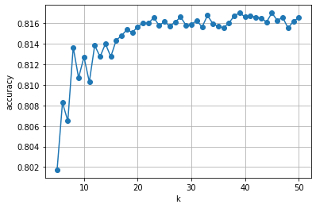

```python
pd.Series(data=accuracies, index=range(5, 51)).plot(xlabel="k", ylabel="accuracy", style="o-", grid=True)
```

The best accuracy was found with:

```python
k = 39
```

With that, the test data can be used to validate the model (holdout method):

```python
neigh = KNeighborsClassifier(n_neighbors=k)
neigh.fit(X, y)
```

```
KNeighborsClassifier(n_neighbors=39)
```

```python
predicted_y = neigh.predict(test_X)
```

```python
correct = sum(test_y == predicted_y)
incorrect = sum(test_y != predicted_y)
total = correct + incorrect

pd.DataFrame(index=["Correct", "Incorrect", "Total"], columns=["N", "%"],
             data=[[correct, 100*correct/total], [incorrect, 100*incorrect/total], [total, 100]])
```

|  | N | % |
| --- | --- | --- |
| Correct | 13265 | 81.475339 |
| Incorrect | 3016 | 18.524661 |
| Total | 16281 | 100.000000 |

## Accuracy, Precision and Recall

```python
from sklearn.metrics import accuracy_score
from sklearn.metrics import classification_report
from sklearn.metrics import plot_roc_curve
```

Considering the target class is ">50K", it is possible to calculate the true positive, the true negative, the false positive and the false negative ratios:

```python
res = {
    "TP": test_df[(predicted_y == ">50K") & (test_df["class"] == ">50K")].shape[0],
    "TN": test_df[(predicted_y == "<=50K") & (test_df["class"] == "<=50K")].shape[0],
    "FP": test_df[(predicted_y == ">50K") & (test_df["class"] == "<=50K")].shape[0],
    "FN": test_df[(predicted_y == "<=50K") & (test_df["class"] == ">50K")].shape[0]
}
res
```

```
{'TP': 1534, 'TN': 11731, 'FP': 704, 'FN': 2312}
```

With these ratios, the precision, recall and F1-score can be calculated as well:

```python
{
    "Precision": res["TP"]/(res["TP"] + res["FP"]),
    "Recall": res["TP"]/(res["TP"] + res["FN"]),
    "F1-score": 2*res["TP"]/(2*res["TP"] + res["FP"] + res["FN"]),
    "Accuracy": accuracy_score(test_y, predicted_y)
}
```

```
{'Precision': 0.6854334226988382,
 'Recall': 0.39885595423816955,
 'F1-score': 0.5042735042735043,
 'Accuracy': 0.8147533935261961}
```

```python
correlation_df = adult_df.copy()
correlation_df["class_as_number"] = 0
correlation_df.loc[correlation_df["class"].str.contains(">50K"), "class_as_number"] = 1

correlation_df.tail()
```

|  | age | workclass | fnlwgt | education | education-num | marital-status | occupation | relationship | race | sex | capital-gain | capital-loss | hours-per-week | native-country | class | class_as_number |
| --- | --- | --- | --- | --- | --- | --- | --- | --- | --- | --- | --- | --- | --- | --- | --- | --- |
| 32556 | 27 | Private | 257302 | Assoc-acdm | 12 | Married-civ-spouse | Tech-support | Wife | White | Female | 0 | 0 | 38 | United-States | <=50K | 0 |
| 32557 | 40 | Private | 154374 | HS-grad | 9 | Married-civ-spouse | Machine-op-inspct | Husband | White | Male | 0 | 0 | 40 | United-States | >50K | 1 |
| 32558 | 58 | Private | 151910 | HS-grad | 9 | Widowed | Adm-clerical | Unmarried | White | Female | 0 | 0 | 40 | United-States | <=50K | 0 |
| 32559 | 22 | Private | 201490 | HS-grad | 9 | Never-married | Adm-clerical | Own-child | White | Male | 0 | 0 | 20 | United-States | <=50K | 0 |
| 32560 | 52 | Self-emp-inc | 287927 | HS-grad | 9 | Married-civ-spouse | Exec-managerial | Wife | White | Female | 15024 | 0 | 40 | United-States | >50K | 1 |

```python
corr = abs(correlation_df.corr())
```

```python
weights = corr.loc["class_as_number"][:-1]
weights
```

```
age               0.234037
fnlwgt            0.009463
education-num     0.335154
capital-gain      0.223329
capital-loss      0.150526
hours-per-week    0.229689
Name: class_as_number, dtype: float64
```

```python
weighted_adult_df = scaled_adult_df.copy()
weighted_test_df = scaled_test_df.copy()

for name in numeric_names:
    weighted_adult_df[name] = weighted_adult_df[name] * weights.loc[name]
    weighted_test_df[name] = weighted_test_df[name] * weights.loc[name]

weighted_adult_df.head()
```

|  | age | fnlwgt | education-num | capital-gain | capital-loss | hours-per-week |
| --- | --- | --- | --- | --- | --- | --- |
| 0 | 0.070532 | 0.000419 | 0.268123 | 0.004855 | 0.0 | 0.091407 |
| 1 | 0.105798 | 0.000456 | 0.268123 | 0.000000 | 0.0 | 0.028125 |
| 2 | 0.067326 | 0.001307 | 0.178749 | 0.000000 | 0.0 | 0.091407 |
| 3 | 0.115416 | 0.001429 | 0.134062 | 0.000000 | 0.0 | 0.091407 |
| 4 | 0.035266 | 0.002096 | 0.268123 | 0.000000 | 0.0 | 0.091407 |

```python
X = weighted_adult_df
test_X = weighted_test_df

neigh = KNeighborsClassifier(n_neighbors=k)
neigh.fit(X, y)

predicted_y = neigh.predict(test_X)

correct = sum(test_y == predicted_y)
incorrect = sum(test_y != predicted_y)
total = correct + incorrect

pd.DataFrame(index=["Correct", "Incorrect", "Total"], columns=["N", "%"],
             data=[[correct, 100*correct/total], [incorrect, 100*incorrect/total], [total, 100]])
```

|  | N | % |
| --- | --- | --- |
| Correct | 13312 | 81.764019 |
| Incorrect | 2969 | 18.235981 |
| Total | 16281 | 100.000000 |

```python
res = {
    "TP": test_df[(predicted_y == ">50K") & (test_df["class"] == ">50K")].shape[0],
    "TN": test_df[(predicted_y == "<=50K") & (test_df["class"] == "<=50K")].shape[0],
    "FP": test_df[(predicted_y == ">50K") & (test_df["class"] == "<=50K")].shape[0],
    "FN": test_df[(predicted_y == "<=50K") & (test_df["class"] == ">50K")].shape[0]
}
res
```

```
{'TP': 1590, 'TN': 11722, 'FP': 713, 'FN': 2256}
```

```python
{
    "Precision": res["TP"]/(res["TP"] + res["FP"]),
    "Recall": res["TP"]/(res["TP"] + res["FN"]),
    "F1-score": 2*res["TP"]/(2*res["TP"] + res["FP"] + res["FN"]),
    "Accuracy": accuracy_score(test_y, predicted_y)
}
```

```
{'Precision': 0.6904038211029092,
 'Recall': 0.41341653666146644,
 'F1-score': 0.5171572613433079,
 'Accuracy': 0.8176401940912721}
```

Using different weights on each feature, the precision was raised to 0.69, the recall was raised to 0.41 and the F1-score was raised to 0.51.

Finally, as a point of comparison, the discretized data is used:

```python
X = discretized_adult_df
test_X = discretized_test_df

neigh = KNeighborsClassifier(n_neighbors=k)
neigh.fit(X, y)

predicted_y = neigh.predict(test_X)

correct = sum(test_y == predicted_y)
incorrect = sum(test_y != predicted_y)
total = correct + incorrect

pd.DataFrame(index=["Correct", "Incorrect", "Total"], columns=["N", "%"],
             data=[[correct, 100*correct/total], [incorrect, 100*incorrect/total], [total, 100]])
```

|  | N | % |
| --- | --- | --- |
| Correct | 13073 | 80.296051 |
| Incorrect | 3208 | 19.703949 |
| Total | 16281 | 100.000000 |

```python
res = {
    "TP": test_df[(predicted_y == ">50K") & (test_df["class"] == ">50K")].shape[0],
    "TN": test_df[(predicted_y == "<=50K") & (test_df["class"] == "<=50K")].shape[0],
    "FP": test_df[(predicted_y == ">50K") & (test_df["class"] == "<=50K")].shape[0],
    "FN": test_df[(predicted_y == "<=50K") & (test_df["class"] == ">50K")].shape[0]
}
res
```

```
{'TP': 1408, 'TN': 11665, 'FP': 770, 'FN': 2438}
```

```python
{
    "Precision": res["TP"]/(res["TP"] + res["FP"]),
    "Recall": res["TP"]/(res["TP"] + res["FN"]),
    "F1-score": 2*res["TP"]/(2*res["TP"] + res["FP"] + res["FN"]),
    "Accuracy": accuracy_score(test_y, predicted_y)
}
```

```
{'Precision': 0.6464646464646465,
 'Recall': 0.3660946437857514,
 'F1-score': 0.4674634794156706,
 'Accuracy': 0.8029605061114182}
```

With these results, it seems the model is not an improvement over the normalized dataset's model.

# Classification Tree

```python
from sklearn.tree import DecisionTreeClassifier
```

While classification trees (or decision trees) can use both numeric and categorical values, **scikit-learn**'s algorithm cannot. With that in mind, the same numeric dataset used in the KNN classifier will also be used with this classifier (although there is no need to scale the values in this case, as this algorithm does not rely on distance between observations).

```python
X = numeric_adult_df
test_X = numeric_test_df

clf = DecisionTreeClassifier()
clf.fit(X, y)

predicted_y = clf.predict(test_X)

correct = sum(test_y == predicted_y)
incorrect = sum(test_y != predicted_y)
total = correct + incorrect

pd.DataFrame(index=["Correct", "Incorrect", "Total"], columns=["N", "%"],
             data=[[correct, 100*correct/total], [incorrect, 100*incorrect/total], [total, 100]])
```

|  | N | % |
| --- | --- | --- |
| Correct | 12560 | 77.145139 |
| Incorrect | 3721 | 22.854861 |
| Total | 16281 | 100.000000 |

With these results, it is estimated that the accuracy of the model is of 77% (aprox.), slightly worse than the KNN classifier.

## Accuracy, Precision and Recall

Considering the target class is ">50K", it is possible to calculate the true positive, the true negative, the false positive and the false negative ratios:

```python
res = {
    "TP": test_df[(predicted_y == ">50K") & (test_df["class"] == ">50K")].shape[0],
    "TN": test_df[(predicted_y == "<=50K") & (test_df["class"] == "<=50K")].shape[0],
    "FP": test_df[(predicted_y == ">50K") & (test_df["class"] == "<=50K")].shape[0],
    "FN": test_df[(predicted_y == "<=50K") & (test_df["class"] == ">50K")].shape[0]
}
res
```

```
{'TP': 2038, 'TN': 10522, 'FP': 1913, 'FN': 1808}
```

With these ratios, the precision, recall and F1-score can be calculated as well:

```python
{
    "Precision": res["TP"]/(res["TP"] + res["FP"]),
    "Recall": res["TP"]/(res["TP"] + res["FN"]),
    "F1-score": 2*res["TP"]/(2*res["TP"] + res["FP"] + res["FN"]),
    "Accuracy": accuracy_score(test_y, predicted_y)
}
```

```
{'Precision': 0.5158187800556822,
 'Recall': 0.5299011960478419,
 'F1-score': 0.5227651660895216,
 'Accuracy': 0.7714513850500584}
```

Hyperparameters can be changed in order to improve the model. For the example below, the minimum number of samples on either side of a split was raised from 1 (default) to 100.

```python
X = numeric_adult_df
test_X = numeric_test_df

clf = DecisionTreeClassifier(min_samples_leaf=100)
clf.fit(X, y)

predicted_y = clf.predict(test_X)

correct = sum(test_y == predicted_y)
incorrect = sum(test_y != predicted_y)
total = correct + incorrect

res = {
    "TP": test_df[(predicted_y == ">50K") & (test_df["class"] == ">50K")].shape[0],
    "TN": test_df[(predicted_y == "<=50K") & (test_df["class"] == "<=50K")].shape[0],
    "FP": test_df[(predicted_y == ">50K") & (test_df["class"] == "<=50K")].shape[0],
    "FN": test_df[(predicted_y == "<=50K") & (test_df["class"] == ">50K")].shape[0]
}
res
```

```
{'TP': 1725, 'TN': 11811, 'FP': 624, 'FN': 2121}
```

```python
{
    "Precision": res["TP"]/(res["TP"] + res["FP"]),
    "Recall": res["TP"]/(res["TP"] + res["FN"]),
    "F1-score": 2*res["TP"]/(2*res["TP"] + res["FP"] + res["FN"]),
    "Accuracy": accuracy_score(test_y, predicted_y)
}
```

```
{'Precision': 0.7343550446998723,
 'Recall': 0.4485179407176287,
 'F1-score': 0.5569007263922519,
 'Accuracy': 0.8313985627418463}
```

# Multilayer Perceptron

```python
from sklearn.neural_network import MLPClassifier
```

To use the multilayer perceptron classifier, the number of hidden layers and the number of neurons must be chosen, based on the problem at hand. Considering the number of inputs (six numeric features) and the number of outputs (one class, ">50K"), it was decided that the neural network would have only one hidden layer, with 3 neurons (about the average of inputs and outputs). Due to the level of complexity of the system, this should be enough to produce a model close to as good as possible. Using the initial dataset, the results were not as good as the previous classifiers:

```python
X = numeric_adult_df
test_X = numeric_test_df

clf = MLPClassifier(hidden_layer_sizes=3, max_iter=1000, random_state=0)
clf.fit(X, y)

predicted_y = clf.predict(test_X)

correct = sum(test_y == predicted_y)
incorrect = sum(test_y != predicted_y)
total = correct + incorrect

pd.DataFrame(index=["Correct", "Incorrect", "Total"], columns=["N", "%"],
             data=[[correct, 100*correct/total], [incorrect, 100*incorrect/total], [total, 100]])
```

|  | N | % |
| --- | --- | --- |
| Correct | 13055 | 80.185492 |
| Incorrect | 3226 | 19.814508 |
| Total | 16281 | 100.000000 |

## Accuracy, Precision and Recall

Considering the target class is ">50K", it is possible to calculate the true positive, the true negative, the false positive and the false negative ratios:

```python
res = {
    "TP": test_df[(predicted_y == ">50K") & (test_df["class"] == ">50K")].shape[0],
    "TN": test_df[(predicted_y == "<=50K") & (test_df["class"] == "<=50K")].shape[0],
    "FP": test_df[(predicted_y == ">50K") & (test_df["class"] == "<=50K")].shape[0],
    "FN": test_df[(predicted_y == "<=50K") & (test_df["class"] == ">50K")].shape[0]
}
res
```

```
{'TP': 681, 'TN': 12374, 'FP': 61, 'FN': 3165}
```

```python
{
    "Precision": res["TP"]/(res["TP"] + res["FP"]),
    "Recall": res["TP"]/(res["TP"] + res["FN"]),
    "F1-score": 2*res["TP"]/(2*res["TP"] + res["FP"] + res["FN"]),
    "Accuracy": accuracy_score(test_y, predicted_y)
}
```

```
{'Precision': 0.9177897574123989,
 'Recall': 0.17706708268330734,
 'F1-score': 0.2968613775065388,
 'Accuracy': 0.8018549229162828}
```

Using the scaled dataset, the results were considerably better and comparable to the previous classifiers:

```python
X = scaled_adult_df
test_X = scaled_test_df

clf = MLPClassifier(hidden_layer_sizes=3, max_iter=1000, random_state=0)
clf.fit(X, y)

predicted_y = clf.predict(test_X)

correct = sum(test_y == predicted_y)
incorrect = sum(test_y != predicted_y)
total = correct + incorrect

pd.DataFrame(index=["Correct", "Incorrect", "Total"], columns=["N", "%"],
             data=[[correct, 100*correct/total], [incorrect, 100*incorrect/total], [total, 100]])
```

|  | N | % |
| --- | --- | --- |
| Correct | 13357 | 82.040415 |
| Incorrect | 2924 | 17.959585 |
| Total | 16281 | 100.000000 |

```python
res = {
    "TP": test_df[(predicted_y == ">50K") & (test_df["class"] == ">50K")].shape[0],
    "TN": test_df[(predicted_y == "<=50K") & (test_df["class"] == "<=50K")].shape[0],
    "FP": test_df[(predicted_y == ">50K") & (test_df["class"] == "<=50K")].shape[0],
    "FN": test_df[(predicted_y == "<=50K") & (test_df["class"] == ">50K")].shape[0]
}
res
```

```
{'TP': 1781, 'TN': 11576, 'FP': 859, 'FN': 2065}
```

With these ratios, the precision, recall and F1-score can be calculated as well:

```python
{
    "Precision": res["TP"]/(res["TP"] + res["FP"]),
    "Recall": res["TP"]/(res["TP"] + res["FN"]),
    "F1-score": 2*res["TP"]/(2*res["TP"] + res["FP"] + res["FN"]),
    "Accuracy": accuracy_score(test_y, predicted_y)
}
```

```
{'Precision': 0.6746212121212121,
 'Recall': 0.4630785231409256,
 'F1-score': 0.5491828553808202,
 'Accuracy': 0.8204041520791107}
```

# Gaussian Naive Bayes

```python
from sklearn.naive_bayes import GaussianNB
from sklearn.naive_bayes import CategoricalNB
```

Starting with just the numeric features:

```python
X = numeric_adult_df
y = adult_df["class"]

test_X = numeric_test_df
test_y = test_df["class"]
```

```python
gnb = GaussianNB()
gnb.fit(X, y)

predicted_y = gnb.predict(test_X)
```

```python
get_stats(test_y, predicted_y)
```

```
TP     1171
TN    11782
FP      653
FN     2675
dtype: int64
```

```
Precision    0.641996
Recall       0.304472
F1-score     0.413051
Accuracy     0.795590
dtype: float64
```

Now, using just the categorical features:

```python
from sklearn.preprocessing import OrdinalEncoder
```

```python
categorical_names = ['workclass', 'education', 'marital-status', 'occupation', 'relationship', 'race', 'sex', 'native-country', 'class']

categorical_adult_df = adult_df.copy()
categorical_adult_df = categorical_adult_df[categorical_names].dropna()
categorical_adult_df.head()
```

|  | workclass | education | marital-status | occupation | relationship | race | sex | native-country | class |
| --- | --- | --- | --- | --- | --- | --- | --- | --- | --- |
| 0 | State-gov | Bachelors | Never-married | Adm-clerical | Not-in-family | White | Male | United-States | <=50K |
| 1 | Self-emp-not-inc | Bachelors | Married-civ-spouse | Exec-managerial | Husband | White | Male | United-States | <=50K |
| 2 | Private | HS-grad | Divorced | Handlers-cleaners | Not-in-family | White | Male | United-States | <=50K |
| 3 | Private | 11th | Married-civ-spouse | Handlers-cleaners | Husband | Black | Male | United-States | <=50K |
| 4 | Private | Bachelors | Married-civ-spouse | Prof-specialty | Wife | Black | Female | Cuba | <=50K |

```python
categorical_test_df = test_df.copy()
categorical_test_df = categorical_test_df[categorical_names].dropna()
categorical_test_df.head()
```

|  | workclass | education | marital-status | occupation | relationship | race | sex | native-country | class |
| --- | --- | --- | --- | --- | --- | --- | --- | --- | --- |
| 0 | Private | 11th | Never-married | Machine-op-inspct | Own-child | Black | Male | United-States | <=50K |
| 1 | Private | HS-grad | Married-civ-spouse | Farming-fishing | Husband | White | Male | United-States | <=50K |
| 2 | Local-gov | Assoc-acdm | Married-civ-spouse | Protective-serv | Husband | White | Male | United-States | >50K |
| 3 | Private | Some-college | Married-civ-spouse | Machine-op-inspct | Husband | Black | Male | United-States | >50K |
| 5 | Private | 10th | Never-married | Other-service | Not-in-family | White | Male | United-States | <=50K |

```python
oe = OrdinalEncoder()

oe.fit(categorical_adult_df.loc[:,"workclass":"native-country"])

categorical_adult_df.loc[:,"workclass":"native-country"] = oe.transform(categorical_adult_df.loc[:,"workclass":"native-country"])
categorical_test_df.loc[:, "workclass":"native-country"] = oe.transform(categorical_test_df.loc[:,"workclass":"native-country"])

display(categorical_adult_df.head())
display(categorical_test_df.head())
```

|  | workclass | education | marital-status | occupation | relationship | race | sex | native-country | class |
| --- | --- | --- | --- | --- | --- | --- | --- | --- | --- |
| 0 | 5.0 | 9.0 | 4.0 | 0.0 | 1.0 | 4.0 | 1.0 | 38.0 | <=50K |
| 1 | 4.0 | 9.0 | 2.0 | 3.0 | 0.0 | 4.0 | 1.0 | 38.0 | <=50K |
| 2 | 2.0 | 11.0 | 0.0 | 5.0 | 1.0 | 4.0 | 1.0 | 38.0 | <=50K |
| 3 | 2.0 | 1.0 | 2.0 | 5.0 | 0.0 | 2.0 | 1.0 | 38.0 | <=50K |
| 4 | 2.0 | 9.0 | 2.0 | 9.0 | 5.0 | 2.0 | 0.0 | 4.0 | <=50K |

|  | workclass | education | marital-status | occupation | relationship | race | sex | native-country | class |
| --- | --- | --- | --- | --- | --- | --- | --- | --- | --- |
| 0 | 2.0 | 1.0 | 4.0 | 6.0 | 3.0 | 2.0 | 1.0 | 38.0 | <=50K |
| 1 | 2.0 | 11.0 | 2.0 | 4.0 | 0.0 | 4.0 | 1.0 | 38.0 | <=50K |
| 2 | 1.0 | 7.0 | 2.0 | 10.0 | 0.0 | 4.0 | 1.0 | 38.0 | >50K |
| 3 | 2.0 | 15.0 | 2.0 | 6.0 | 0.0 | 2.0 | 1.0 | 38.0 | >50K |
| 5 | 2.0 | 0.0 | 4.0 | 7.0 | 1.0 | 4.0 | 1.0 | 38.0 | <=50K |

```python
X = categorical_adult_df.loc[:,"workclass":"native-country"]
y = categorical_adult_df["class"]

test_X = categorical_test_df.loc[:,"workclass":"native-country"]
test_y = categorical_test_df["class"]
```

```python
cnb = CategoricalNB()
cnb.fit(X, y)

predicted_y = cnb.predict(test_X)
```

```python
get_stats(test_y, predicted_y)
```

```
TP    2738
TN    9220
FP    2140
FN     962
dtype: int64
```

```
Precision    0.561296
Recall       0.740000
F1-score     0.638377
Accuracy     0.794024
dtype: float64
```

```
<sklearn.metrics._plot.roc_curve.RocCurveDisplay at 0x229ec0d8a88>
```

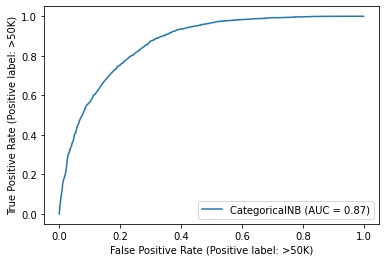

```python
plot_roc_curve(cnb, test_X, test_y, pos_label=">50K")
```